# CourseProject

Ken Hironaka

05/21/2015

# Introduction

With the advent of smart personal devices like Fitbit, Nike FuelBand, etc., we now have access to large amounts of personal activity big data. The purpose of this exercise is to determine whether we can apply machine learning to identify now just *how much* activity is done, but *how well* it is done. Specifically, when provided data on how people have done barbell lifts correctly and incorrectly in 5 different ways, the goal is to see if we can build predictors that can auto detect the ways it has been done.

# Analysis

## Libraries

The following libraries were used as part of this exercise.

```
library(caret)
library(corrplot)
library(randomForest)
```

## Data Cleaning

Before any analysis or training can be performed, the data must be cleaned in such a way that it can easily be consumed. The input training data has many features that are either empty or ‘NA’. The first step is to remove such features. Moreover, the input also contains many features like **user_name** and **raw_timestamp_X** that are not useful for training purposes. They also need to be removed from the training set. This is also important for reducing the training computational complexity. This cleaning yielded a total of **52** features.

```
data = read.csv("pml-training.csv", na.strings = c("NA", "", " "))
data_clean = data[,is.na(data[1,]) == 0]
data_clean = data_clean[,-(1:7)]
```

## Training Data Analysis

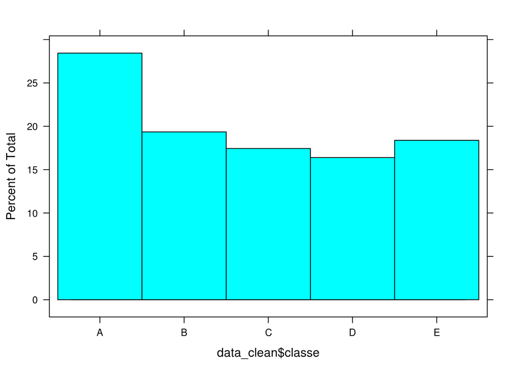

Moreover, it is also important to check that there are no over correlation among features in the data. The correlation matrix indicates that aside from a small number of exceptions, in general this is not a concern.

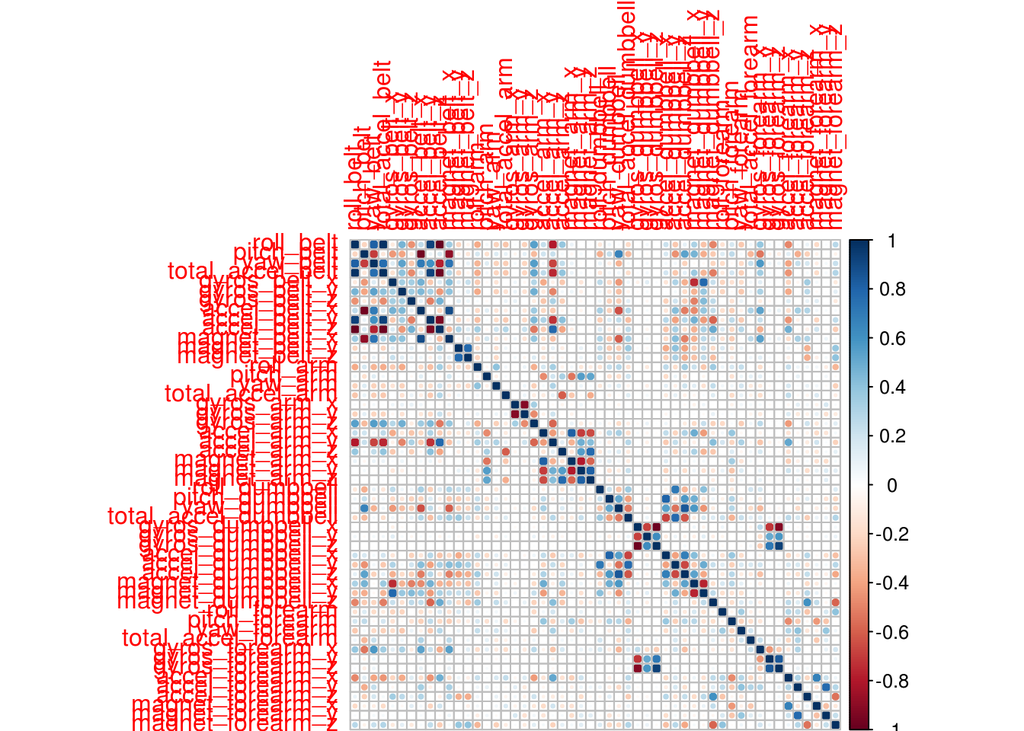

# Training

For the learning algorithm, Random Forest will be employed because of below * There is little worry for over correlation among features * Random Forest can automatically adapt to non-linear models, unlike in linear logistic regression where the complexity of the model has to be pre-defined

```
inTrain = createDataPartition(data_clean$classe, p =0.75, list = F)
training = data_clean[inTrain,]
validation = data_clean[-inTrain,]
```

Training was done using all remaining features in the data set.

```
fit <- train(classe ~ ., data = training, method = "rf")
```

Details of the resulting model are below.

```r
load("fit.dat")
print(fit)
```

```
## Random Forest
##
## 14718 samples
##    52 predictors
##     5 classes: 'A', 'B', 'C', 'D', 'E'
##
## No pre-processing
## Resampling: Bootstrapped (25 reps)
##
## Summary of sample sizes: 14718, 14718, 14718, 14718, 14718, 14718, ...
##
## Resampling results across tuning parameters:
##
##   mtry  Accuracy   Kappa      Accuracy SD  Kappa SD
##    2    0.9897302  0.9870084  0.001557724  0.001971893
##   27    0.9897352  0.9870153  0.001981827  0.002507124
##   52    0.9774606  0.9714896  0.002691597  0.003412058
##
## Accuracy was used to select the optimal model using  the largest value.
## The final value used for the model was mtry = 27.
```

## Cross Validation

```r
load("validation.dat")
confusionMatrix(predict(fit, validation), validation$classe)
```

```
## Confusion Matrix and Statistics
##
##           Reference
## Prediction    A    B    C    D    E
##          A 1395    3    0    0    0
##          B    0  944    3    0    1
##          C    0    2  850    9    4
##          D    0    0    2  794    3
##          E    0    0    0    1  893
##
## Overall Statistics
##
##                Accuracy : 0.9943
##                  95% CI : (0.9918, 0.9962)
##     No Information Rate : 0.2845
##     P-Value [Acc > NIR] : < 2.2e-16
##
##                   Kappa : 0.9928
##  Mcnemar's Test P-Value : NA
##
## Statistics by Class:
##
##                      Class: A Class: B Class: C Class: D Class: E
## Sensitivity            1.0000   0.9947   0.9942   0.9876   0.9911
## Specificity            0.9991   0.9990   0.9963   0.9988   0.9998
## Pos Pred Value         0.9979   0.9958   0.9827   0.9937   0.9989
## Neg Pred Value         1.0000   0.9987   0.9988   0.9976   0.9980
## Prevalence             0.2845   0.1935   0.1743   0.1639   0.1837
## Detection Rate         0.2845   0.1925   0.1733   0.1619   0.1821
## Detection Prevalence   0.2851   0.1933   0.1764   0.1629   0.1823
## Balanced Accuracy      0.9996   0.9969   0.9952   0.9932   0.9954
```

# Prediction

Each of the predictions were written to a seprate file.

```
prediction = predict(fit, validation)

pml_write_files = function(x){
  n = length(x)
  for(i in 1:n){
    filename = paste0("problem_id_",i,".txt")
    write.table(x[i],file=filename,quote=FALSE,row.names=FALSE,col.names=FALSE)
  }
}

pml_write_files(prediction)
```

# Conclusion

The result showed that the given input data set was sufficient for predicting the manner in which a person performed barbell lifts. Moreever the result also showed that without more complicated methods like combining predictors, the prediction model can predict highly accurately.